# R Notebook

```r
library(tidyverse)
```

#1_Take the data in the dataset qb_revenue_breakdown and make a stacked bar chart showing the sources of revenue across the two years in the dataset.

```r
revenue_breakdown <- CodeClanData::qb_revenue_breakdown
revenue_breakdown
```

```r
ggplot(revenue_breakdown)+
  aes(x = Year, y = Revenue, fill = Product) +
geom_col()
```

[output not shown]

#2_Make a line chart showing monthly sales of the “flagship product” - the KwikBit Unit1 - over the last year. This data is inside qb_monthly_sales, but you will need to use subset.

```r
monthly_sales <- CodeClanData::qb_monthly_sales
monthly_sales
```

```r
kwikbit_monthly_sales <- monthly_sales %>%
    filter(Cashflow == "Kwikbit Unit 1 Sales")
kwikbit_monthly_sales
```

```r
ggplot(kwikbit_monthly_sales) +
  aes(x = Date, y = Amount) +
  geom_line() +
  labs(title = "Kwikbit Unit 1 Sales") +
    theme_light()
```

[output not shown]

#3_Make a line chart showing monthly revenue and costs over the last year. This data is also in qb_monthly_sales.

```r
kwikbit_revenue_and_costs <- monthly_sales %>%
    filter(Cashflow != "Kwikbit Unit 1 Sales")
kwikbit_revenue_and_costs
```

or

```r
revenue_and_costs <- subset(qb_monthly_sales, Cashflow != "Kwikbit Unit 1 Sales")
```

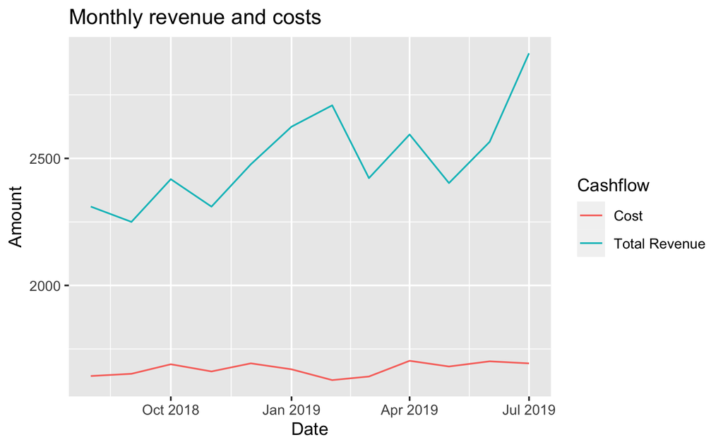

```r
ggplot(kwikbit_revenue_and_costs) +
    aes(x = Date, y = Amount, colour = Cashflow) +
    geom_line() +
    labs(title = "Monthly revenue and costs")
```

```r
NA
NA
```

#4Show annual sales of personal fitness trackers over the last 5 years broken down by company as a ribbon plot (use geom_area). This data is in qb_competitors.

```r
competitors <- CodeClanData::qb_competitors
competitors
```

```r
ggplot(competitors) +
    aes(x = Year, y = Revenue, fill = Company) +
    geom_area() +
    labs(title = "Annual Sales Personal Fitness Trackers")
```

[output not shown]

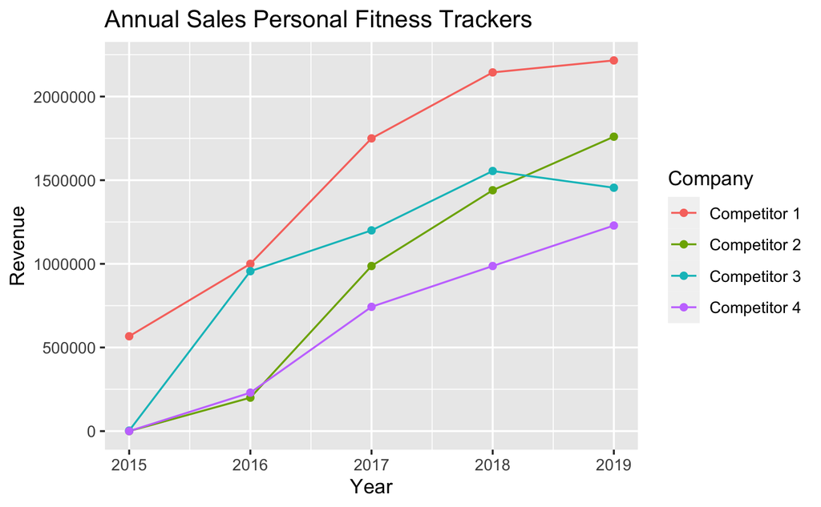

```r
ggplot(competitors) +
    aes(x = Year, y = Revenue, colour = Company) +
    geom_line() +
  geom_point() +
    labs(title = "Annual Sales Personal Fitness Trackers")
```

```r
NA
```

#6Now the company wants to compare the number of steps that their device counts vs. their competitors. #Make a line graph of the number of steps throughout time #and use faceting to compare between individuals and people. #Data is in qb_device_data.

```r
device_data <- CodeClanData::qb_device_data
device_data
```

```r
names(device_data)
```

```r
device_data_mins <- device_data %>%
  filter(counts != 0) %>%
  mutate(total_minutes = 60*hours + mins)
device_data_mins
```

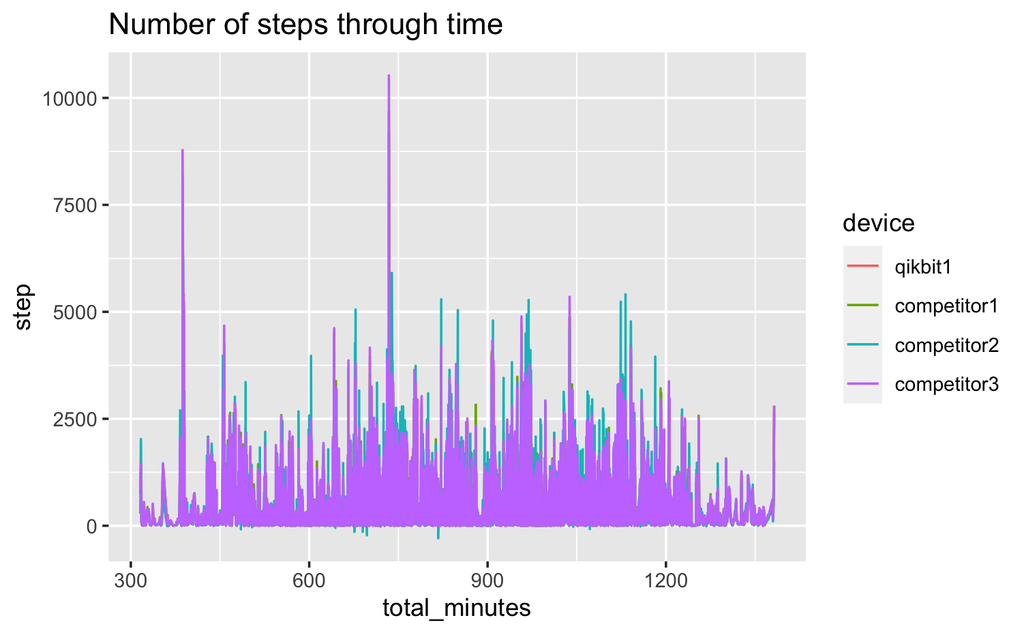

```r
ggplot(device_data_mins) +
    aes(x = total_minutes, y = counts, colour = device) +
    geom_line() +
    labs(title = "Number of steps through time", y = "step")
```

```r
NA
NA
```

#have now realised this refers to different data but run out of time!

```r
ggplot(device_data_mins) +
    aes(x = total_minutes, y = counts, colour = device) +
    geom_line() +
    labs(title = "Number of steps through time", y = "step") +
  facet_wrap()
```

```
Error in wrap_as_facets_list(facets) :
  argument "facets" is missing, with no default
```